## Homework Assignment 4

#### Due Friday, February 24 at 11:59 PM CT

### Preliminaries

- Directories
  - COURSE/homework/
  - COURSE/homework/hw04/
  - COURSE/data/
  - COURSE/scripts/
- Files
  - COURSE/homework/hw04/hw04.Rmd
  - COURSE/data/ORD-2017.csv
  - COURSE/data/ORD-2018.csv
  - COURSE/data/ORD-2019.csv
  - COURSE/data/ORD-2020.csv
  - COURSE/data/ORD-2021.csv
  - COURSE/scripts/viridis.R

### Aims

- Practice data visualization using ggplot2
- Practice data wrangling with dplyr
- Practice reading in data and working with dates
- Explore additional airport waiting time data

### Problems

This assignment involves five data sets involving international flights arriving to Chicago’s O’Hare airport from January 1, 2017 through December 31, 2021 with one separate file for each year. Each file has been cleaned from the original HTML.

Each data set is in a separate CSV file: `ORD-2017.csv`, `ORD-2018.csv`, `ORD-2019.csv`, `ORD-2020.csv`, `ORD-2021.csv`.

This code chunk reads in these five data sets and combines them into a single data set.

```r
ord = map_dfr(2017:2021, ~{
  return ( read_csv(str_c("../../data/ORD-", .x, ".csv")) )
})
```

1. Make the following changes to the data set `ord`.
- Add columns for:
  - *year*;
  - *month* (character valued, use month abbreviations, Jan - Dec);
  - *day* (day of the month); and
  - *wday* (day of the week, character valued, use day abbreviations, Sun - Sat).
- Reorder the variables so that these new variables all appear directly after the date column.
- Remove the `terminal` variable.
- Rename:
  - *all_total* to *passengers*;
  - *all_flights* to *flights*; and
  - *all_booths* to *booths*.
- Arrange the rows by date and hour.
- Print all columns of the first 5 rows of this modified data frame
- Print the dimensions of this modified data frame

```r
ord = ord %>%
  mutate(year = year(date)) %>%
  mutate(month = as.character(month(date, label = TRUE, abbr = TRUE)))%>%
  mutate(month_day = day(date)) %>%
  mutate(week_day = as.character(wday(date,label = TRUE,abbr = TRUE)))%>%
  relocate(year, month, month_day, week_day, .after = date) %>%
  select(-terminal) %>%
  rename(passengers = all_total, flights = all_flights, booths = all_booths) %>%
  arrange(date,hour)
head(ord, 5)
```

```
## # A tibble: 5 × 24
##   airport date        year month month_day week_…¹ hour  us_av…² us_ma…³ non_u…⁴
##   <chr>   <date>     <dbl> <chr>     <int> <chr>   <chr>   <dbl>   <dbl>   <dbl>
## 1 ORD     2017-01-01  2017 Jan           1 Sun     0700…       7      24      12
## 2 ORD     2017-01-01  2017 Jan           1 Sun     0800…       5      25      13
## 3 ORD     2017-01-01  2017 Jan           1 Sun     0900…       5      37      32
## 4 ORD     2017-01-01  2017 Jan           1 Sun     1000…       8      20       8
## 5 ORD     2017-01-01  2017 Jan           1 Sun     1100…      30      89      40
## # … with 14 more variables: non_us_max_wait <dbl>, all_avg_wait <dbl>,
## #   all_max_wait <dbl>, all_n_0_15 <dbl>, all_n_16_30 <dbl>, all_n_31_45 <dbl>,
## #   all_n_46_60 <dbl>, all_n_61_90 <dbl>, all_n_91_120 <dbl>,
## #   all_n_120_plus <dbl>, all_excluded <dbl>, passengers <dbl>, flights <dbl>,
## #   booths <dbl>, and abbreviated variable names ¹week_day, ²us_avg_wait,
## #   ³us_max_wait, ⁴non_us_avg_wait
```

```r
print(dim(ord))
```

```
## [1] 31344    24
```

2. Are there any dates in the range from January 1, 2017 through December 31, 2021 that are missing? If so, which ones?

```r
all_data = expand_grid(date = seq(ymd("2017-01-01"), ymd("2021-12-31"), 1))
ord_data = ord %>%
  select(airport, date) %>%
  distinct()
all_data %>%
  anti_join(ord_data)
```

```
## # A tibble: 5 × 1
##   date
##   <date>
## 1 2018-05-08
## 2 2019-10-28
## 3 2019-10-29
## 4 2019-10-30
## 5 2020-02-08
```

3. Modify the `ord` data set by:
- Adding a variable named `time_of_day` which categorizes the `hour` variable in the following way:
  - midnight to 4am (“0000 - 0100” through “0300 - 0400”) is “overnight”
  - 4am to 8am is “early morning”
  - 8am to noon is “morning”
  - noon to 4pm is “afternoon”
  - 4pm to 8pm is “early evening”
  - 8pm to midnight is “late evening”
- After adding the `time_of_day` variable, this chunk of code will reorder the levels to match the times and not alphabetically.
  - This is useful so you get the desired order in summary tables and plots.
  - The function `fct_relevel()` is part of the **forcats** package in **tidyverse** which we will not study in depth.
  - Use this code (or something like it) in your solution.

```r
ord = ord %>%
  mutate(time_of_day = case_when(
    (str_detect(hour, "0000 - 0100|0100 - 0200|0200 - 0300|0300 - 0400") ~ 'overnight'),
    (str_detect(hour, "0400 - 0500|0500 - 0600|0600 - 0700|0700 - 0800") ~ 'early morning'),
    (str_detect(hour, "0800 - 0900|0900 - 1000|1000 - 1100|1100 - 1200") ~ 'morning'),
    (str_detect(hour, "1200 - 1300|1300 - 1400|1400 - 1500|1500 - 1600") ~ 'afternoon'),
    (str_detect(hour, "1600 - 1700|1700 - 1800|1800 - 1900|1900 - 2000") ~ 'early afternoon'),
    (str_detect(hour, "2000 - 2100|2100 - 2200|2200 - 2300|2300 - 0000") ~ 'late evening'))) %>%
  mutate(time_of_day =
           fct_relevel(time_of_day,
                       c("overnight", "early morning", "morning", "afternoon", "early evening", "late evening")))
ord
```

```
## # A tibble: 31,344 × 25
##    airport date        year month month_…¹ week_…² hour  us_av…³ us_ma…⁴ non_u…⁵
##    <chr>   <date>     <dbl> <chr>    <int> <chr>   <chr>   <dbl>   <dbl>   <dbl>
##  1 ORD     2017-01-01  2017 Jan          1 Sun     0700…       7      24      12
##  2 ORD     2017-01-01  2017 Jan          1 Sun     0800…       5      25      13
##  3 ORD     2017-01-01  2017 Jan          1 Sun     0900…       5      37      32
##  4 ORD     2017-01-01  2017 Jan          1 Sun     1000…       8      20       8
##  5 ORD     2017-01-01  2017 Jan          1 Sun     1100…      30      89      40
##  6 ORD     2017-01-01  2017 Jan          1 Sun     1200…      19      83      39
##  7 ORD     2017-01-01  2017 Jan          1 Sun     1300…      10      51      17
##  8 ORD     2017-01-01  2017 Jan          1 Sun     1400…      10      63      23
##  9 ORD     2017-01-01  2017 Jan          1 Sun     1500…      14      66      31
## 10 ORD     2017-01-01  2017 Jan          1 Sun     1600…      13      44      24
## # … with 31,334 more rows, 15 more variables: non_us_max_wait <dbl>,
## #   all_avg_wait <dbl>, all_max_wait <dbl>, all_n_0_15 <dbl>,
## #   all_n_16_30 <dbl>, all_n_31_45 <dbl>, all_n_46_60 <dbl>, all_n_61_90 <dbl>,
## #   all_n_91_120 <dbl>, all_n_120_plus <dbl>, all_excluded <dbl>,
## #   passengers <dbl>, flights <dbl>, booths <dbl>, time_of_day <fct>, and
## #   abbreviated variable names ¹month_day, ²week_day, ³us_avg_wait,
## #   ⁴us_max_wait, ⁵non_us_avg_wait
```

- Create a summary table which counts the number of rows for each `time_of_day` and `hour` combination. Verify that the top ten rows of your data set match these values.

```
   time_of_day   hour            n
   <fct>         <chr>       <int>
 1 overnight     0000 - 0100  1345
 2 overnight     0100 - 0200   538
 3 overnight     0200 - 0300   167
 4 overnight     0300 - 0400   125
 5 early morning 0400 - 0500   520
 6 early morning 0500 - 0600  1024
 7 early morning 0600 - 0700  1355
 8 early morning 0700 - 0800  1286
 9 morning       0800 - 0900  1434
10 morning       0900 - 1000  1447
```

- Create an additional summary table which calculates the total number of flights which arrive during each of these time periods. This table will have six rows.
- Print the table.

```r
ord %>%
  group_by(time_of_day, hour) %>%
  count(time_of_day, hour) %>%
  summarize(time_of_day, n) %>%
  slice(1:10)
```

```
## # A tibble: 24 × 3
## # Groups:   time_of_day [6]
##    time_of_day   hour            n
##    <fct>         <chr>       <int>
##  1 overnight     0000 - 0100  1345
##  2 overnight     0100 - 0200   538
##  3 overnight     0200 - 0300   167
##  4 overnight     0300 - 0400   125
##  5 early morning 0400 - 0500   520
##  6 early morning 0500 - 0600  1024
##  7 early morning 0600 - 0700  1355
##  8 early morning 0700 - 0800  1286
##  9 morning       0800 - 0900  1434
## 10 morning       0900 - 1000  1447
## # … with 14 more rows
```

```r
time_of_day_sum = ord %>%
  group_by(time_of_day, hour) %>%
  summarize(n = n())
prob3 = ord %>%
  group_by(time_of_day) %>%
  summarize(number_flights = sum(flights))
prob3
```

```
## # A tibble: 6 × 2
##   time_of_day     number_flights
##   <fct>                    <dbl>
## 1 overnight                 3456
## 2 early morning             6073
## 3 morning                  14293
## 4 afternoon                44029
## 5 late evening             10171
## 6 early afternoon          38545
```

4. Use a bar graph to display the total number of flights in each time period as calculated in the previous problem. There should be six categories of time period from “overnight” to “late evening”. Add a title and meaningful axis labels.

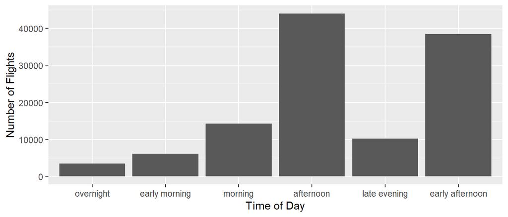

```r
ggplot(prob3, aes(x = time_of_day, y = number_flights))+
  geom_col()+
  xlab("Time of Day")+
  ylab("Number of Flights")
```

5. Create a data summary table with the average daily number of passengers by month and year.
- Display this data summary with a bar chart where month is on the x-axis and average daily passenger counts are on the y axis
- Add meaningful axis labels and a title to this graph.
- Change the y axis scale labels so values are regular numbers with commas. *(Use `scale_y_continuous()` as below)*
- Display the graph with a different facet for each year

```r
## modify this code block

## data summary
prob5 = ord %>%
  select(month,year,passengers) %>%
  group_by(month,year) %>%
  summarize(AVERAGE = mean(passengers))
prob5
```

```
## # A tibble: 60 × 3
## # Groups:   month [12]
##    month  year AVERAGE
##    <chr> <dbl>   <dbl>
##  1 Apr    2017   815.
##  2 Apr    2018   849.
##  3 Apr    2019   889.
##  4 Apr    2020    63.5
##  5 Apr    2021   323.
##  6 Aug    2017   936.
##  7 Aug    2018   922.
##  8 Aug    2019   988.
##  9 Aug    2020   214.
## 10 Aug    2021   622.
## # … with 50 more rows
```

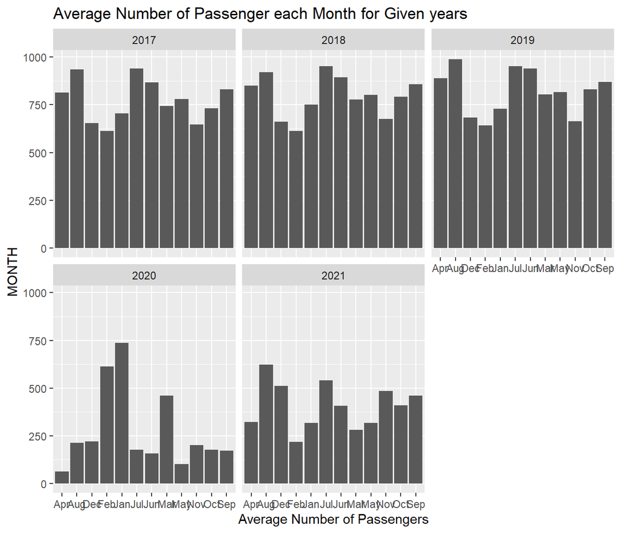

```r
  ## add code

## plot the table
ggplot(prob5, aes(x = month, y = AVERAGE)) +
  geom_col() +
  xlab("Average Number of Passengers")+
  ylab("MONTH")+
  ggtitle("Average Number of Passenger each Month for Given years")+
  facet_wrap(vars(year))
```

```r
 scale_y_continuous(label = scales::comma)
```

```
## <ScaleContinuousPosition>
##  Range:
##  Limits:    0 --    1
```

6. What striking feature is apparent in this graph? What explains this feature of the data?

> The chart of 2020 is different from the other 4 charts. There were less number of passengers in 2020 because of the situation of covid-19 and lockdown. The months ranging from april to december had comparatively less number of passengers.
7. Investigate the average number of passengers per day of the week for the years 2017–2019.
- For each day of the week (Sunday – Saturday), calculate the average number of arriving daily passengers to ORD on international flights. Display this table sorted from highest to lowest average. *(Hint: you need to total passengers by date and day of week before taking averages.)*
- Print the entire table

```r
ord1 = ord %>%
  group_by(week_day) %>%
  filter(year == 2017 | year == 2018 | year == 2019) %>%
  summarize(passenger_sum = sum(passengers),
            day = n())
ord_avg = ord1 %>%
  mutate(average_per_day = passenger_sum/day) %>%
  arrange(desc(average_per_day))
ord_avg
```

```
## # A tibble: 7 × 4
##   week_day passenger_sum   day average_per_day
##   <chr>            <dbl> <int>           <dbl>
## 1 Sat            2804113  3090            907.
## 2 Sun            2609996  2998            871.
## 3 Mon            2352517  2938            801.
## 4 Fri            2348997  2945            798.
## 5 Wed            2154440  2910            740.
## 6 Thu            2123433  2887            736.
## 7 Tue            2080826  2871            725.
```

8. Identify the 20 dates with the highest total number of arriving passengers. How many of these dates are the day of the week identified in the previous problem with the highest average?

```r
ord2 = ord %>%
  select(date, week_day, passengers) %>%
  arrange(desc(passengers)) %>%
  head(20)
ord2 %>%
  filter(week_day == "Sat")
```

```
## # A tibble: 8 × 3
##   date       week_day passengers
##   <date>     <chr>         <dbl>
## 1 2017-10-21 Sat            3779
## 2 2019-06-22 Sat            3710
## 3 2018-08-25 Sat            3381
## 4 2017-07-08 Sat            3376
## 5 2017-07-08 Sat            3372
## 6 2018-08-11 Sat            3372
## 7 2018-09-08 Sat            3356
## 8 2019-03-23 Sat            3352
```